# Proyecto-Exploracion de Datos

Luis Diego Montero Vargas

2025-11-18

# Descripción Completa del Dataset *Sample - Superstore*

El dataset **Sample - Superstore** contiene información detallada sobre transacciones comerciales realizadas por una tienda minorista en Estados Unidos.

Incluye datos sobre ventas, clientes, productos, logística y rentabilidad con un total de 9,994 registros y 21 variables relacionadas con transacciones individuales.

Por lo que para efecto de proyecto se presentara y se expondra un analasis minusioso y critico referente a dicho dataset para una mejor interpretacion y comprension.

## 2. Descripción Detallada de Cada Variable

### 2.1 Identificadores

#### **Row ID**

- Tipo: entero
- Identificador secuencial de fila
- **Observación:** No aporta valor analítico. Es redundante, ya que existen otros identificadores más relevantes.

#### **Order ID**

- Identificador del pedido
- No es único debido a que un pedido puede contener múltiples productos
- **Observación:** Representa estructura de cabecera-detalle. Necesita agregación para análisis a nivel de pedido.

#### **Order Date**

- Fecha de compra (texto)
- **Observación:** Requiere conversión a formato fecha para análisis temporal.

#### **Ship Date**

- Fecha de envío del pedido
- **Observación:** Permite analizar tiempos de despacho una vez convertida a datetime.

#### **Ship Mode**

Categorías posibles: - *Same Day*  
- *First Class*  
- *Second Class*  
- *Standard Class*

**Observación:** Útil para análisis logístico, aunque faltan datos de costos de envío o transportistas.

### 2.2 Información del Cliente

#### **Customer ID**

- Identificador único del cliente

#### **Customer Name**

- Nombre del cliente
- **Observación:** Es texto libre; se necesita hacer un procesamiento previo.

#### **Segment**

Categorías: - Consumer  
- Corporate  
- Home Office

**Observación:** Segmentación simple basada en tipo de cliente; puede ampliarse para análisis de valor o fidelización.

### 2.3 Ubicación Geográfica

Variables incluidas: - Country  
- City  
- State  
- Postal Code  
- Region

### 2.4 Información del Producto

#### **Product ID**

- Identificador del producto

#### **Category**

Tres categorías principales:

- Furniture
- Office Supplies
- Technology

#### **Sub-Category**

Categorías más específicas como chairs, phones, binders, etc.

#### **Product Name**

- Nombre descriptivo del producto
- **Observación:** Texto extenso que puede requerir limpieza para análisis como NLP o minería de texto.

### 2.5 Métricas de Venta

#### **Sales**

- Monto vendido por línea de pedido
- Rango aproximado: 0.44 a 22,638
- **Observación:** Distribución sesgada con valores atípicos altos.

#### **Quantity**

- Cantidad vendida (1 a 14)

#### **Discount**

- Porcentaje de descuento aplicado (0 a 0.8)
- **Observación:** Descuentos elevados tienden a afectar la rentabilidad de los productos.

#### **Profit**

- Ganancia generada por línea de pedido
- Promedio: 28.65
- Mínimo: -6599.98
- Máximo: 8399.98
- **Observación:** La existencia de valores altamente negativos indica problemas en la estructura de costos o aplicación de descuentos.

## 4. Conclusión

El dataset **Sample - Superstore** es potente y versátil para el estudio y proyecto, sin embargo, requiere pasos previos de limpieza, conversión de tipos y revisión de outliers para obtener análisis más precisos y representativos, por lo que acontinuacion se va a realizar un analisis de los datos y sus variables, para asi justificar y determinar que variables usar y cuales no en el proyecto.

# Informacion de datos

Informacion de dataset https://www.kaggle.com/datasets/vivek468/superstore-dataset-final

Row ID => Unique ID for each row.  
Order ID => Unique Order ID for each Customer.  
Order Date => Order Date of the product.  
Ship Date => Shipping Date of the Product.  
Ship Mode=> Shipping Mode specified by the Customer.  
Customer ID => Unique ID to identify each Customer.  
Customer Name => Name of the Customer.  
Segment => The segment where the Customer belongs.  
Country => Country of residence of the Customer.  
City => City of residence of of the Customer.  
State => State of residence of the Customer.  
Postal Code => Postal Code of every Customer.  
Region => Region where the Customer belong.  
Product ID => Unique ID of the Product.  
Category => Category of the product ordered.  
Sub-Category => Sub-Category of the product ordered.  
Product Name => Name of the Product  
Sales => Sales of the Product.  
Quantity => Quantity of the Product.  
Discount => Discount provided.  
Profit => Profit/Loss incurred.

# Carga de librerias

```r
library(dplyr)
```

```r
library(ggplot2)
```

# Analisis del set de datos

### 1. Carga de los datos

```r
datos <-read.csv("Sample - Superstore.csv", sep = ",")
```

### 2. Estadisticas basicas

```r
head(datos)
```

```
##   Row.ID       Order.ID Order.Date  Ship.Date      Ship.Mode Customer.ID
## 1      1 CA-2016-152156  11/8/2016 11/11/2016   Second Class    CG-12520
## 2      2 CA-2016-152156  11/8/2016 11/11/2016   Second Class    CG-12520
## 3      3 CA-2016-138688  6/12/2016  6/16/2016   Second Class    DV-13045
## 4      4 US-2015-108966 10/11/2015 10/18/2015 Standard Class    SO-20335
## 5      5 US-2015-108966 10/11/2015 10/18/2015 Standard Class    SO-20335
## 6      6 CA-2014-115812   6/9/2014  6/14/2014 Standard Class    BH-11710
##     Customer.Name   Segment       Country            City      State
## 1     Claire Gute  Consumer United States       Henderson   Kentucky
## 2     Claire Gute  Consumer United States       Henderson   Kentucky
## 3 Darrin Van Huff Corporate United States     Los Angeles California
## 4  Sean O'Donnell  Consumer United States Fort Lauderdale    Florida
## 5  Sean O'Donnell  Consumer United States Fort Lauderdale    Florida
## 6 Brosina Hoffman  Consumer United States     Los Angeles California
##   Postal.Code Region      Product.ID        Category Sub.Category
```

[output cut: 20 more lines]

```r
tail(datos)
```

```
##      Row.ID       Order.ID Order.Date  Ship.Date      Ship.Mode Customer.ID
## 9989   9989 CA-2017-163629 11/17/2017 11/21/2017 Standard Class    RA-19885
## 9990   9990 CA-2014-110422  1/21/2014  1/23/2014   Second Class    TB-21400
## 9991   9991 CA-2017-121258  2/26/2017   3/3/2017 Standard Class    DB-13060
## 9992   9992 CA-2017-121258  2/26/2017   3/3/2017 Standard Class    DB-13060
## 9993   9993 CA-2017-121258  2/26/2017   3/3/2017 Standard Class    DB-13060
## 9994   9994 CA-2017-119914   5/4/2017   5/9/2017   Second Class    CC-12220
##         Customer.Name   Segment       Country        City      State
## 9989     Ruben Ausman Corporate United States      Athens    Georgia
## 9990 Tom Boeckenhauer  Consumer United States       Miami    Florida
## 9991      Dave Brooks  Consumer United States  Costa Mesa California
## 9992      Dave Brooks  Consumer United States  Costa Mesa California
## 9993      Dave Brooks  Consumer United States  Costa Mesa California
## 9994     Chris Cortes  Consumer United States Westminster California
##      Postal.Code Region      Product.ID        Category Sub.Category
```

[output cut: 20 more lines]

```r
summary(datos)
```

```
##      Row.ID       Order.ID          Order.Date         Ship.Date
##  Min.   :   1   Length:9994        Length:9994        Length:9994
##  1st Qu.:2499   Class :character   Class :character   Class :character
##  Median :4998   Mode  :character   Mode  :character   Mode  :character
##  Mean   :4998
##  3rd Qu.:7496
##  Max.   :9994
##   Ship.Mode         Customer.ID        Customer.Name        Segment
##  Length:9994        Length:9994        Length:9994        Length:9994
##  Class :character   Class :character   Class :character   Class :character
##  Mode  :character   Mode  :character   Mode  :character   Mode  :character
##
##
##
##    Country              City              State            Postal.Code
##  Length:9994        Length:9994        Length:9994        Min.   : 1040
##  Class :character   Class :character   Class :character   1st Qu.:23223
##  Mode  :character   Mode  :character   Mode  :character   Median :56431
##                                                           Mean   :55190
##                                                           3rd Qu.:90008
##                                                           Max.   :99301
##     Region           Product.ID          Category         Sub.Category
##  Length:9994        Length:9994        Length:9994        Length:9994
##  Class :character   Class :character   Class :character   Class :character
##  Mode  :character   Mode  :character   Mode  :character   Mode  :character
##
##
##
##  Product.Name           Sales              Quantity        Discount
##  Length:9994        Min.   :    0.444   Min.   : 1.00   Min.   :0.0000
##  Class :character   1st Qu.:   17.280   1st Qu.: 2.00   1st Qu.:0.0000
##  Mode  :character   Median :   54.490   Median : 3.00   Median :0.2000
##                     Mean   :  229.858   Mean   : 3.79   Mean   :0.1562
##                     3rd Qu.:  209.940   3rd Qu.: 5.00   3rd Qu.:0.2000
##                     Max.   :22638.480   Max.   :14.00   Max.   :0.8000
##      Profit
##  Min.   :-6599.978
##  1st Qu.:    1.729
##  Median :    8.666
##  Mean   :   28.657
##  3rd Qu.:   29.364
##  Max.   : 8399.976
```

```r
str(datos)
```

```
## 'data.frame':    9994 obs. of  21 variables:
##  $ Row.ID       : int  1 2 3 4 5 6 7 8 9 10 ...
##  $ Order.ID     : chr  "CA-2016-152156" "CA-2016-152156" "CA-2016-138688" "US-2015-108966" ...
##  $ Order.Date   : chr  "11/8/2016" "11/8/2016" "6/12/2016" "10/11/2015" ...
##  $ Ship.Date    : chr  "11/11/2016" "11/11/2016" "6/16/2016" "10/18/2015" ...
##  $ Ship.Mode    : chr  "Second Class" "Second Class" "Second Class" "Standard Class" ...
##  $ Customer.ID  : chr  "CG-12520" "CG-12520" "DV-13045" "SO-20335" ...
##  $ Customer.Name: chr  "Claire Gute" "Claire Gute" "Darrin Van Huff" "Sean O'Donnell" ...
##  $ Segment      : chr  "Consumer" "Consumer" "Corporate" "Consumer" ...
##  $ Country      : chr  "United States" "United States" "United States" "United States" ...
##  $ City         : chr  "Henderson" "Henderson" "Los Angeles" "Fort Lauderdale" ...
##  $ State        : chr  "Kentucky" "Kentucky" "California" "Florida" ...
##  $ Postal.Code  : int  42420 42420 90036 33311 33311 90032 90032 90032 90032 90032 ...
##  $ Region       : chr  "South" "South" "West" "South" ...
##  $ Product.ID   : chr  "FUR-BO-10001798" "FUR-CH-10000454" "OFF-LA-10000240" "FUR-TA-10000577" ...
##  $ Category     : chr  "Furniture" "Furniture" "Office Supplies" "Furniture" ...
##  $ Sub.Category : chr  "Bookcases" "Chairs" "Labels" "Tables" ...
##  $ Product.Name : chr  "Bush Somerset Collection Bookcase" "Hon Deluxe Fabric Upholstered Stacking Chairs, Rounded Back" "Self-Adhesive Address Labels for Typewriters by Universal" "Bretford CR4500 Series Slim Rectangular Table" ...
##  $ Sales        : num  262 731.9 14.6 957.6 22.4 ...
##  $ Quantity     : int  2 3 2 5 2 7 4 6 3 5 ...
##  $ Discount     : num  0 0 0 0.45 0.2 0 0 0.2 0.2 0 ...
##  $ Profit       : num  41.91 219.58 6.87 -383.03 2.52 ...
```

### 3. Validar si existen campos vacios en el dataset

```r
colSums(is.na(datos))
```

```
##        Row.ID      Order.ID    Order.Date     Ship.Date     Ship.Mode
##             0             0             0             0             0
##   Customer.ID Customer.Name       Segment       Country          City
##             0             0             0             0             0
##         State   Postal.Code        Region    Product.ID      Category
##             0             0             0             0             0
##  Sub.Category  Product.Name         Sales      Quantity      Discount
##             0             0             0             0             0
##        Profit
##             0
```

# Limpieza de datos

### 1. Explicacion del tipo de limpieza a realizar

Sobre todo el set de datos compartido por parte de la empresa se requiere dar un enfoque de los siguientes aspectos.

- Performance por categoría y subcategoría
- Productos más rentables vs menos rentables
- Relación entre descuentos y profit

En este caso no se requieren de muchos de los datos que se encuentran en el dataset, por lo que se procederá a eliminarlos del mismo para crear un dataframe enfocado específicamente en la parte de ventas buscando los resultados propuestos.

El enfoque del proyecto es rentabilidad, categorías, subcategorías, descuentos, ventas, cantidad, profit, y regiones.

##### **Estas son las columnas que NO aportan nada a este análisis:**

| Columna | Motivo para eliminar |
| --- | --- |
| **Row ID** | Es solo un índice. No aporta información. |
| **Order ID** | No se analiza rendimiento por orden. |
| **Customer ID** | No relevante en análisis de rentabilidad general. |
| **Customer Name** | No aporta al análisis. |
| **City**, **State**, **Postal Code** | No se está haciendo análisis geográfico detallado. |
| **Country** | Todos los registros son de USA → no aporta. |
| **Product ID** | No analizamos a nivel SKU, sino categoría/subcategoría. |

##### **Columnas que SI se mantienen**

| Columna | Motivo para mantener |
| --- | --- |
| **Order Date** | Permite explorar tendencias temporales en ventas, descuentos y profit |
| **Ship Date** | Se decide mantener para apoyar la busqueda de tendencias |
| **Ship Mode** | Puede influir en costos o márgenes, tambien es útil para segmentar resultados en el performance. |
| **Segment** | Útil para comparar rentabilidad entre segmentos (Consumer, Corporate, Home Office). |
| **Region** | Permite comparar performance por región, útil para rentabilidad y tendencias. |
| **Category** | Princial variable para análisis de performance |
| **Sub-Category** | Permite identificar subcategorías más o menos rentable |
| **Product Name** | Necesario para identificar productos más rentables vs menos rentables |
| **Sales** | Métrica central para performance y análisis de rentabilidad |
| **Quantity** | Permite calcular métricas adicionales como profit por unidad |
| **Discount** | Para analizar la relación entre descuentos y profit |
| **Profit** | Clave para evaluar la rentabilidad |

### 2. Creacion del dataframe

```r
dataframeDatos <- subset(datos, select = -c(Row.ID, Order.ID, Customer.ID, Customer.Name, Country,
                                            City, State, Postal.Code, Product.ID))
```

Con esto creamos el nuevo dataframe con las columnas necesarias para su análisis

```r
head(dataframeDatos)
```

```
##   Order.Date  Ship.Date      Ship.Mode   Segment Region        Category
## 1  11/8/2016 11/11/2016   Second Class  Consumer  South       Furniture
## 2  11/8/2016 11/11/2016   Second Class  Consumer  South       Furniture
## 3  6/12/2016  6/16/2016   Second Class Corporate   West Office Supplies
## 4 10/11/2015 10/18/2015 Standard Class  Consumer  South       Furniture
## 5 10/11/2015 10/18/2015 Standard Class  Consumer  South Office Supplies
## 6   6/9/2014  6/14/2014 Standard Class  Consumer   West       Furniture
##   Sub.Category                                                     Product.Name
## 1    Bookcases                                Bush Somerset Collection Bookcase
## 2       Chairs      Hon Deluxe Fabric Upholstered Stacking Chairs, Rounded Back
## 3       Labels        Self-Adhesive Address Labels for Typewriters by Universal
## 4       Tables                    Bretford CR4500 Series Slim Rectangular Table
## 5      Storage                                   Eldon Fold 'N Roll Cart System
## 6  Furnishings Eldon Expressions Wood and Plastic Desk Accessories, Cherry Wood
##      Sales Quantity Discount    Profit
## 1 261.9600        2     0.00   41.9136
## 2 731.9400        3     0.00  219.5820
## 3  14.6200        2     0.00    6.8714
## 4 957.5775        5     0.45 -383.0310
## 5  22.3680        2     0.20    2.5164
## 6  48.8600        7     0.00   14.1694
```

### 3. Conversión de fechas a tipo date

Las variables **Order.Date** y **Ship.Date** actualmente son de tipo character, por lo que se debe pasar a convertir en formato date para su análisis

Formato actual **Order.Date**

```r
class(dataframeDatos$Order.Date)
```

```
## [1] "character"
```

```r
summary(dataframeDatos$Order.Date)
```

```
##    Length     Class      Mode
##      9994 character character
```

```r
head(dataframeDatos$Order.Date)
```

```
## [1] "11/8/2016"  "11/8/2016"  "6/12/2016"  "10/11/2015" "10/11/2015"
## [6] "6/9/2014"
```

Formato actual **Ship.Date**

```r
class(dataframeDatos$Ship.Date)
```

```
## [1] "character"
```

```r
summary(dataframeDatos$Ship.Date)
```

```
##    Length     Class      Mode
##      9994 character character
```

```r
head(dataframeDatos$Ship.Date)
```

```
## [1] "11/11/2016" "11/11/2016" "6/16/2016"  "10/18/2015" "10/18/2015"
## [6] "6/14/2014"
```

Cambio de Order.Date

```r
dataframeDatos$Order.Date <- as.Date(dataframeDatos$Order.Date, format = "%m/%d/%Y")
```

```r
class(dataframeDatos$Order.Date)
```

```
## [1] "Date"
```

```r
head(dataframeDatos$Order.Date)
```

```
## [1] "2016-11-08" "2016-11-08" "2016-06-12" "2015-10-11" "2015-10-11"
## [6] "2014-06-09"
```

Cambio de Ship.Date

```r
dataframeDatos$Ship.Date <- as.Date(dataframeDatos$Ship.Date, format = "%m/%d/%Y")
```

```r
class(dataframeDatos$Ship.Date)
```

```
## [1] "Date"
```

```r
head(dataframeDatos$Ship.Date)
```

```
## [1] "2016-11-11" "2016-11-11" "2016-06-16" "2015-10-18" "2015-10-18"
## [6] "2014-06-14"
```

### 4. Conversión de datos

```r
class(dataframeDatos$Quantity)
```

```
## [1] "integer"
```

```r
class(dataframeDatos$Discount)
```

```
## [1] "numeric"
```

```r
class(dataframeDatos$Sales)
```

```
## [1] "numeric"
```

```r
class(dataframeDatos$Profit)
```

```
## [1] "numeric"
```

Como podemos observar en las variables **Sales**, **Profit**, **Quantity**, **Discount** que deberian ser de tipo numerico. En ese caso se procede a convertir todos esos datos a tipo numerico para su análisis apesar de algunos ya esten en ese formato.

```r
dataframeDatos$Sales <- as.numeric(dataframeDatos$Sales)
dataframeDatos$Profit <- as.numeric(dataframeDatos$Profit)
dataframeDatos$Quantity <- as.numeric(dataframeDatos$Quantity)
dataframeDatos$Discount <- as.numeric(dataframeDatos$Discount)
```

Validamos los tipos de clase de los datos

```r
class(dataframeDatos$Sales)
```

```
## [1] "numeric"
```

```r
class(dataframeDatos$Profit)
```

```
## [1] "numeric"
```

```r
class(dataframeDatos$Quantity)
```

```
## [1] "numeric"
```

```r
class(dataframeDatos$Discount)
```

```
## [1] "numeric"
```

### Validacion de valores no negativos

En este punto validamos que los valores como **Sales**, **Quantity** y **Discount** no tengan ningún tipo de valor negativo ya que por si naturaleza deben ser siempre ≥ 0

```r
summary(dataframeDatos$Sales)
```

```
##      Min.   1st Qu.    Median      Mean   3rd Qu.      Max.
##     0.444    17.280    54.490   229.858   209.940 22638.480
```

```r
summary(dataframeDatos$Quantity)
```

```
##    Min. 1st Qu.  Median    Mean 3rd Qu.    Max.
##    1.00    2.00    3.00    3.79    5.00   14.00
```

```r
summary(dataframeDatos$Discount)
```

```
##    Min. 1st Qu.  Median    Mean 3rd Qu.    Max.
##  0.0000  0.0000  0.2000  0.1562  0.2000  0.8000
```

boxplot options

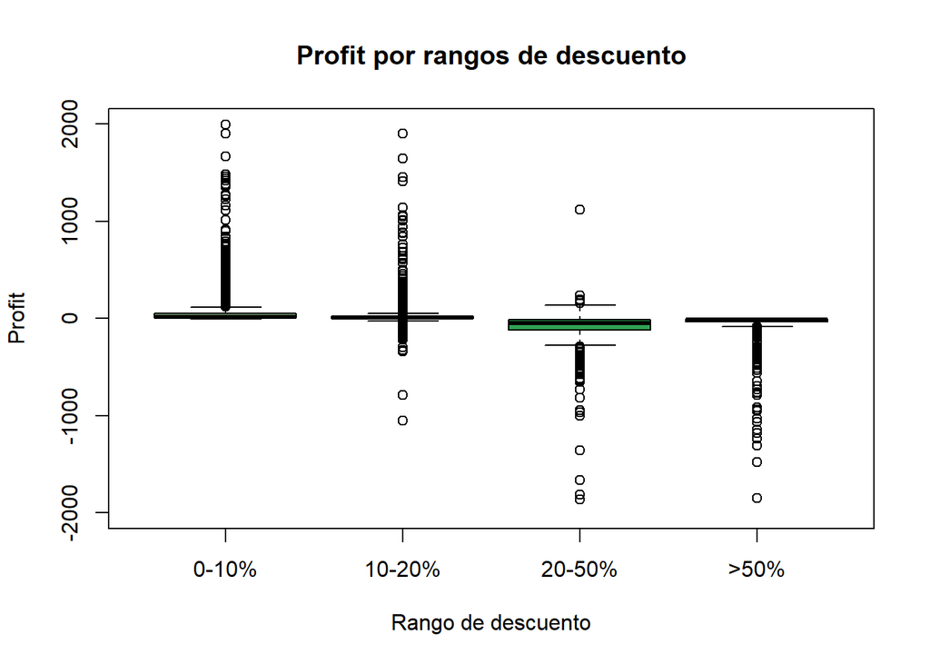

```r
dataframeDatos$RangoDescuento <- cut(
  dataframeDatos$Discount,
  breaks = c(-Inf, 0.10, 0.20, 0.50, Inf),
  labels = c('0-10%', '10-20%', '20-50%', '>50%')
)
boxplot(Profit ~ RangoDescuento,
        data = dataframeDatos,
        main = 'Profit por rangos de descuento',
        xlab = 'Rango de descuento',
        ylab = 'Profit',
        col = c('#a1d99b', '#74c476', '#31a354', '#006d2c'),
        ylim = c(-2000, 2000))  # Ajusta según tus datos
```

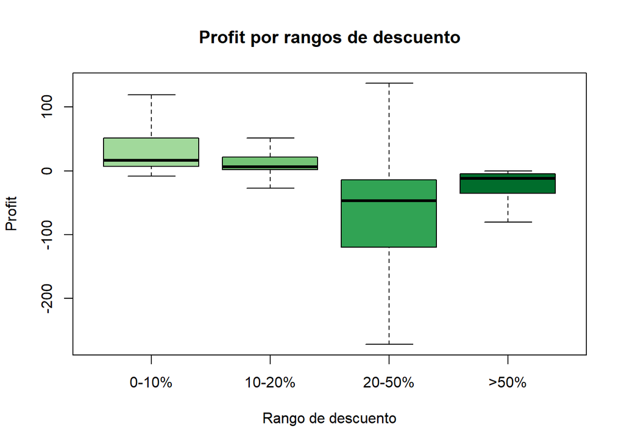

```r
boxplot(Profit ~ RangoDescuento,
        data = dataframeDatos,
        main = 'Profit por rangos de descuento',
        xlab = 'Rango de descuento',
        ylab = 'Profit',
        col = c('#a1d99b', '#74c476', '#31a354', '#006d2c'),
        outline = FALSE)  # No grafica los outliers
```

[figure not shown]

```r
# Boxplot mejorado de Profit por rangos de descuento
boxplot(Sales ~ RangoDescuento,
        data = dataframeDatos,
        main = 'Profit por rangos de descuento',
        xlab = 'Rango de descuento',
        ylab = 'Profit',
        col = c('#a1d99b', '#74c476', '#31a354', '#006d2c'),
        border = "black",
        outline = FALSE
        )
```

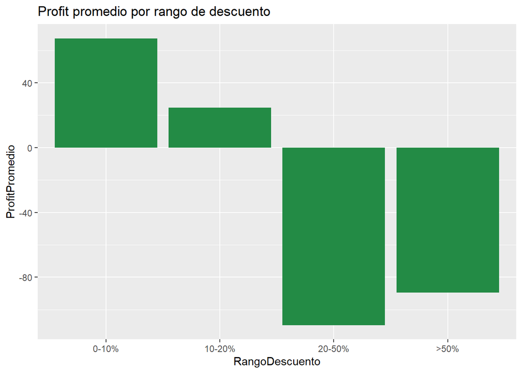

```r
dataframeDatos %>%
  mutate(RangoDescuento = cut(
    Discount,
    breaks = c(-Inf, 0.10, 0.20, 0.50, Inf),
    labels = c("0-10%", "10-20%", "20-50%", ">50%")
  )) %>%
  group_by(RangoDescuento) %>%
  summarise(ProfitPromedio = mean(Profit, na.rm = TRUE)) %>%
  ggplot(aes(x = RangoDescuento, y = ProfitPromedio)) +
  geom_col(fill = "#238b45") +
  labs(title = "Profit promedio por rango de descuento")
```

En este gráfico se observa, que el rango de descuento 0–10% es el único claramente rentable, el rango de 10–20% aún mantiene profit promedio positivo, pero considerablemente más bajo, a partir del 20% de descuento, el profit promedio se vuelve negativo y el rango >50% también genera pérdidas significativas. Se comprueba los análisis anteriores, la estrategia de descuentos no está funcionando como palanca comercial positiva, solo está reduciendo la rentabilidad.

# Shapiro

### Performance por categoría

```r
muestra <- sample(dataframeDatos$Sales[dataframeDatos$Category == "Office Supplies"], 5000)
```

```r
shapiro.test(dataframeDatos$Sales[dataframeDatos$Category == "Furniture"])
```

```
##
##  Shapiro-Wilk normality test
##
## data:  dataframeDatos$Sales[dataframeDatos$Category == "Furniture"]
## W = 0.64963, p-value < 2.2e-16
```

```r
shapiro.test(muestra)
```

```
##
##  Shapiro-Wilk normality test
##
## data:  muestra
## W = 0.26123, p-value < 2.2e-16
```

```r
shapiro.test(dataframeDatos$Sales[dataframeDatos$Category == "Technology"])
```

```
##
##  Shapiro-Wilk normality test
##
## data:  dataframeDatos$Sales[dataframeDatos$Category == "Technology"]
## W = 0.33257, p-value < 2.2e-16
```

### Performance por subcategoría

```r
shapiro.test(dataframeDatos$Sales[dataframeDatos$Sub.Category == "Chairs"])
```

```
##
##  Shapiro-Wilk normality test
##
## data:  dataframeDatos$Sales[dataframeDatos$Sub.Category == "Chairs"]
## W = 0.73229, p-value < 2.2e-16
```

```r
shapiro.test(dataframeDatos$Sales[dataframeDatos$Sub.Category == "Phones"])
```

```
##
##  Shapiro-Wilk normality test
##
## data:  dataframeDatos$Sales[dataframeDatos$Sub.Category == "Phones"]
## W = 0.65151, p-value < 2.2e-16
```

```r
shapiro.test(dataframeDatos$Sales[dataframeDatos$Sub.Category == "Binders"])
```

```
##
##  Shapiro-Wilk normality test
##
## data:  dataframeDatos$Sales[dataframeDatos$Sub.Category == "Binders"]
## W = 0.21208, p-value < 2.2e-16
```

```r
shapiro.test(dataframeDatos$Sales[dataframeDatos$Sub.Category == "Storage"])
```

```
##
##  Shapiro-Wilk normality test
##
## data:  dataframeDatos$Sales[dataframeDatos$Sub.Category == "Storage"]
## W = 0.69202, p-value < 2.2e-16
```

### Productos más rentables vs menos rentables

```r
medianProfit <- median(dataframeDatos$Profit)

shapiro.test(dataframeDatos$Profit[dataframeDatos$Profit >= medianProfit])  # más rentables
```

```
##
##  Shapiro-Wilk normality test
##
## data:  dataframeDatos$Profit[dataframeDatos$Profit >= medianProfit]
## W = 0.22624, p-value < 2.2e-16
```

```r
shapiro.test(dataframeDatos$Profit[dataframeDatos$Profit < medianProfit])   # menos rentables
```

```
##
##  Shapiro-Wilk normality test
##
## data:  dataframeDatos$Profit[dataframeDatos$Profit < medianProfit]
## W = 0.155, p-value < 2.2e-16
```

#### Más rentables vs menos rentables

Tanto los productos más rentables como los menos rentables presentan p-value < 0.05. Por tanto, el profit no es normal en ningún grupo. Esto muestra que la rentabilidad está muy dispersa y concentrada en pocos productos.

### Relación entre descuentos y profit

```r
muestraDiscount <- sample(dataframeDatos$Discount, 5000)
muestraProfit <- sample(dataframeDatos$Profit, 5000)
```

```r
shapiro.test(muestraDiscount)
```

```
##
##  Shapiro-Wilk normality test
##
## data:  muestraDiscount
## W = 0.71084, p-value < 2.2e-16
```

```r
shapiro.test(muestraProfit)
```

```
##
##  Shapiro-Wilk normality test
##
## data:  muestraProfit
## W = 0.25871, p-value < 2.2e-16
```

Discount

El p-value del Shapiro-Wilk es menor a 0.05, lo que indica que la variable Discount no sigue una distribución normal. Esto es esperado porque los descuentos suelen concentrarse en intervalos específicos.

Profit

El p-value es menor a 0.05, por lo que Profit no presenta normalidad. Esto coincide con los datos comerciales, donde hay muchos valores bajos y pocos valores extremos altos o negativos.